# Reducción de dimensiones con conservación de la probabilidad conjunta en bases de datos mixtas agrupadas, estratificadas y con mecanismos de pérdida MNAR mediante el método MIRIMFA

$$\begin{equation}
\label{eq:Xhat1_14}
\begin{split}
\widehat{\mathbf{X}}'^{(1)\intercal}_{[1,4]}=&
\left[\begin{array}{ccccccccccccccccccccccccccccccccccccccccccccccc}0.157
& 0.006 & -0.013 & 0.147 & 0.069 & -0.029 &
0.800 & 0.096 & -0.113 & -0.014 & -0.021 & -0.050
& -0.023 & 0.067 & 0.055 & 0.046 & -0.027 &
0.079 & -0.062 & 0.910 & 0.029 & -0.022 & -0.027
& -0.052 & 0.151 & -0.102 & 0.043 & -0.012 &
0.021 & 0.156 & 0.002 & 0.002 & 0.028 & 0.027 &
-0.035 & 0.913 & 0.087 & -0.023 & 0.049 & 0.067
& -0.014 & -0.056 & -0.042 & -0.031 & -0.015 &
-0.015 & 0.049\\ 0.748 & 0.891 & 0.881 & 0.753 &
0.831 & 0.904 & 0.093 & 0.710 & 0.991 & 0.883 &
0.877 & 0.990 & 0.867 & 0.833 & 0.855 & 0.817 &
0.937 & 0.783 & 0.959 & -0.058 & 0.924 & 0.887 &
0.937 & 0.994 & 0.686 & 0.945 & 0.873 & 0.970 &
0.933 & 0.709 & 0.920 & 0.920 & 0.928 & 0.861 &
0.942 & -0.014 & 0.786 & 0.905 & 0.864 & 0.853 &
0.974 & 0.968 & 0.962 & 0.945 & 0.976 & 0.934 &
0.866\\ 0.014 & -0.078 & -0.066 & 0.008 & 0.001 &
-0.073 & 0.094 & 0.036 & 0.046 & -0.064 & -0.030
& -0.016 & -0.002 & 0.002 & 0.010 & -0.048 &
0.002 & -0.057 & -0.005 & 0.046 & -0.002 & -0.067
& 0.002 & -0.011 & -0.015 & -0.008 & -0.060 &
-0.001 & 0.002 & -0.044 & -0.059 & -0.059 & 0.003
& -0.041 & 0.001 & 0.113 & -0.040 & -0.067 &
0.018 & 0.033 & 0.004 & -0.007 & 0.009 & 0.012 &
0.007 & 0.010 & 0.022\\ 0.917 & 1.028 & 1.020 &
0.923 & 0.927 & 1.026 & 0.873 & 0.916 & 0.865 &
1.018 & 0.979 & 0.925 & 0.943 & 0.926 & 0.915 &
0.991 & 0.921 & 1.019 & 0.922 & 0.962 & 0.925 &
1.022 & 0.921 & 0.922 & 0.975 & 0.954 & 1.017 &
0.916 & 0.919 & 1.011 & 1.008 & 1.008 & 0.921 &
0.994 & 0.922 & 0.864 & 1.004 & 1.024 & 0.910 &
0.884 & 0.912 & 0.930 & 0.914 & 0.913 & 0.910 &
0.915 & 0.907\\ 0.057 & 0.475 & -0.022 & -0.015 &
0.010 & 0.050 & -0.064 & 0.242 & 0.080 & -0.022
& 0.169 & 0.618 & 0.636 & 0.001 & 0.051 & 0.668
& 0.049 & -0.063 & 0.170 & -0.132 & 0.443 &
-0.076 & 0.049 & 0.617 & 0.118 & 0.016 & 0.388 &
0.531 & 0.472 & -0.089 & 0.477 & 0.477 & 0.442 &
0.158 & 0.004 & -0.008 & 0.016 & 0.048 & 0.031 &
0.635 & 0.530 & 0.040 & 0.108 & 0.047 & 0.530 &
0.092 & 0.040\\ 0.666 & 0.438 & 0.830 & 0.720 &
0.716 & 0.773 & 0.684 & 0.747 & 0.742 & 0.833 &
0.729 & 0.244 & 0.427 & 0.726 & 0.681 & 0.336 &
0.699 & 0.859 & 0.628 & 0.818 & 0.364 & 0.874 &
0.699 & 0.249 & 0.765 & 0.881 & 0.491 & 0.294 &
0.344 & 0.869 & 0.421 & 0.421 & 0.370 & 0.685 &
0.737 & 0.639 & 0.810 & 0.778 & 0.705 & 0.268 &
0.300 & 0.708 & 0.660 & 0.710 & 0.303 & 0.669 &
0.701\\ 0.031 & -0.015 & 0.017 & 0.024 & 0.058 &
-0.015 & -0.087 & 0.903 & 0.549 & 0.017 & 0.341
& 0.082 & 0.759 & 0.057 & 0.040 & 0.431 & 0.071
& 0.005 & 0.228 & -0.147 & -0.117 & 0.012 &
0.071 & 0.082 & 0.392 & 0.498 & -0.168 & -0.071
& -0.087 & -0.028 & -0.122 & -0.122 & -0.116 &
0.027 & 0.067 & -0.125 & 0.015 & -0.052 & 0.039
& 0.330 & -0.071 & 0.031 & 0.049 & 0.072 &
-0.070 & 0.039 & 0.040\\ 0.858 & 0.982 & 0.914 &
0.859 & 0.820 & 0.951 & 1.044 & 0.058 & 0.303 &
0.915 & 0.599 & 0.811 & 0.212 & 0.821 & 0.836 &
0.545 & 0.798 & 0.939 & 0.644 & 1.186 & 1.019 &
0.916 & 0.798 & 0.813 & 0.571 & 0.422 & 1.137 &
0.966 & 0.987 & 0.980 & 1.084 & 1.084 & 1.020 &
0.915 & 0.800 & 1.107 & 0.940 & 0.993 & 0.839 &
0.583 & 0.967 & 0.838 & 0.826 & 0.800 & 0.968 &
0.838 & 0.839\\ -0.002 & 0.368 & 0.045 & -0.048 &
-0.021 & 0.084 & -0.101 & 0.506 & 0.152 & 0.044
& 0.267 & 0.370 & 0.716 & -0.028 & -0.014 &
0.646 & -0.005 & 0.024 & 0.137 & -0.046 & 0.187
& 0.009 & -0.005 & 0.368 & 0.271 & 0.202 & 0.245
& 0.248 & 0.212 & -0.005 & 0.306 & 0.306 & 0.185
& 0.148 & -0.035 & -0.072 & 0.071 & 0.069 &
-0.030 & 0.463 & 0.246 & -0.021 & 0.021 & -0.010
& 0.245 & 0.010 & -0.026\\ 0.924 & 0.526 & 0.865
& 0.971 & 0.940 & 0.820 & 1.069 & 0.505 & 0.801
& 0.866 & 0.673 & 0.523 & 0.257 & 0.946 & 0.926
& 0.299 & 0.913 & 0.894 & 0.785 & 1.021 & 0.691
& 0.902 & 0.913 & 0.524 & 0.692 & 0.750 & 0.633
& 0.629 & 0.668 & 0.926 & 0.571 & 0.571 & 0.692
& 0.759 & 0.944 & 1.041 & 0.843 & 0.829 & 0.941
& 0.465 & 0.630 & 0.922 & 0.880 & 0.916 & 0.631
& 0.893 & 0.935\\ 0.000 & 0.167 & 0.003 & -0.030
& -0.023 & 0.004 & 0.085 & 0.672 & 0.224 & 0.002
& 0.259 & 0.155 & 0.684 & -0.028 & -0.036 &
0.527 & -0.041 & 0.016 & 0.098 & 0.158 & -0.009
& -0.021 & -0.041 & 0.153 & 0.340 & 0.266 &
0.039 & 0.028 & 0.014 & 0.007 & 0.076 & 0.076 &
-0.011 & 0.067 & -0.061 & 0.117 & 0.045 & -0.019
& -0.048 & 0.349 & 0.026 & -0.075 & -0.044 &
-0.046 & 0.025 & -0.045 & -0.045\\ 0.939 & 0.670 &
0.975 & 0.990 & 0.970 & 0.960 & 0.909 & 0.033 &
0.597 & 0.978 & 0.593 & 0.605 & -0.064 & 0.978 &
0.977 & 0.147 & 0.977 & 0.977 & 0.765 & 0.883 &
0.873 & 1.017 & 0.977 & 0.609 & 0.512 & 0.601 &
0.866 & 0.798 & 0.835 & 1.002 & 0.791 & 0.791 &
0.878 & 0.859 & 1.013 & 0.873 & 0.929 & 0.996 &
0.998 & 0.355 & 0.802 & 1.024 & 0.972 & 0.987 &
0.805 & 0.981 & 0.995\\ \end{array}\right]
\end{split}
\end{equation}$$

$$\begin{equation}
\label{eq:Xhat1_21}
\begin{split}
\widehat{\mathbf{X}}'^{(1)\intercal}_{[2,1]}=&
\left[\begin{array}{cccccccc}34.352 & 39.123 & 108.671
& 66.748 & 69.992 & 69.266 & 67.558 & 77.174\\
16.908 & 12.090 & 9.564 & 15.891 & 16.281 & 0.575
& 9.772 & 0.606\\ \end{array}\right]
\end{split}
\end{equation}$$

$$\begin{equation}
\label{eq:Xhat1_22}
\begin{split}
\widehat{\mathbf{X}}'^{(1)\intercal}_{[2,2]}=&
\left[\begin{array}{cccccccc}-0.081 & 0.131 & -0.100 &
-0.127 & -0.143 & 0.622 & 0.058 & 0.633\\ 1.042 &
0.831 & 0.907 & 1.076 & 1.075 & 0.115 & 0.817 &
0.151\\ 0.907 & 1.020 & -0.437 & 1.027 & 0.979 &
0.119 & 0.043 & 0.687\\ -0.004 & -0.104 & 1.306 &
-0.151 & -0.117 & 0.623 & 0.899 & 0.053\\
\end{array}\right]
\end{split}
\end{equation}$$

$$\begin{equation}
\label{eq:Xhat1_23}
\begin{split}
\widehat{\mathbf{X}}'^{(1)\intercal}_{[2,3]}=&
\left[\begin{array}{cccccccc}0.604 & 0.666 & 0.874 &
0.592 & 0.668 & 1.100 & 0.994 & 0.981\\ 0.268 &
0.186 & 0.207 & 0.293 & 0.211 & -0.104 & -0.061
& -0.039\\ 0.106 & 0.228 & 0.796 & 0.219 & 0.101
& 0.859 & 0.188 & 0.837\\ 0.619 & 0.533 & 0.094
& 0.461 & 0.544 & -0.100 & 0.670 & -0.140\\ -0.044
& 0.172 & 0.085 & -0.055 & -0.057 & 0.907 &
0.146 & 0.895\\ 0.727 & 0.565 & 1.031 & 0.767 &
0.737 & 0.103 & 0.759 & 0.039\\ -0.010 & 0.183 &
0.128 & 0.002 & -0.033 & 0.850 & 0.056 & 0.869\\
0.820 & 0.688 & 0.884 & 0.882 & 0.898 & 0.145 &
0.838 & 0.159\\ 0.074 & 0.260 & -0.071 & 0.044 &
0.050 & 0.893 & 0.073 & 0.933\\ 0.636 & 0.501 &
0.999 & 0.633 & 0.598 & -0.001 & 0.799 & -0.111\\
\end{array}\right]
\end{split}
\end{equation}$$

$$\begin{equation}
\label{eq:Xhat1_24}
\begin{split}
\widehat{\mathbf{X}}'^{(1)\intercal}_{[2,4]}=&
\left[\begin{array}{cccccccc}-0.046 & -0.084 & 0.252 &
0.010 & -0.091 & -0.043 & -0.217 & -0.040\\ 0.943 &
0.982 & 0.812 & 0.925 & 1.034 & 1.073 & 1.189 &
1.050\\ 0.011 & 0.033 & 0.500 & 0.129 & 0.128 &
0.194 & 0.262 & 0.167\\ 0.963 & 0.942 & 0.506 &
0.879 & 0.875 & 0.778 & 0.693 & 0.830\\ -0.064 &
0.097 & 0.074 & -0.099 & -0.096 & 0.405 & 0.227
& 0.365\\ 0.939 & 0.862 & 0.950 & 1.067 & 1.078
& 0.583 & 0.828 & 0.682\\ 0.025 & 0.190 & 0.334
& 0.030 & 0.039 & -0.091 & 0.632 & -0.125\\ 0.934
& 0.786 & 0.670 & 0.986 & 0.964 & 1.068 & 0.299
& 1.151\\ -0.008 & 0.151 & -0.127 & -0.061 & -0.068
& 0.098 & 0.182 & 0.130\\ 0.901 & 0.749 & 1.006
& 0.937 & 0.934 & 0.736 & 0.721 & 0.701\\ -0.044
& 0.103 & 0.007 & -0.067 & -0.100 & -0.096 &
0.210 & -0.072\\ 1.067 & 0.844 & 1.012 & 1.147 &
1.181 & 1.052 & 0.641 & 1.060\\ \end{array}\right]
\end{split}
\end{equation}$$

Al igual que con la imputación original, se sustituyen los valores imputados en la matriz de datos observados original para evitar variación en éstos. Luego de varias iteraciones, se calcula el cambio en las variables latentes entre iteraciones consecutivas y se detiene el proceso cuando se excede el número predeterminado de imputaciones o:
$$\begin{equation}
\Delta \mathbf{V} = \sqrt{\sum_{k=1}^K \sum_{s=1}^S
\left(\mathbf{V}_{ks}^{(l)} -
\mathbf{V}_{ks}^{(l-1)}\right)^2}<\epsilon,
\end{equation}$$
donde $\epsilon$ es un valor arbitrario.

Al hacer este proceso con $\epsilon=1\times 10^{-6}$, se obtuvo:

**Mostrar submatrices: X[+](imputación compromiso)**

$$\begin{equation}
\label{eq:Xplus_11}
\begin{split}
\widehat{\mathbf{X}}^{\intercal}_{[+][1,1]}=&
\left[\begin{array}{ccccccccccccccccccccccccccccccccccccccccccccccc}4.000
& 5.000 & 5.000 & 5.000 & 5.000 & 5.000 & 5.000
& 5.000 & 5.000 & 6.000 & 6.000 & 6.000 & 6.000
& 6.000 & 6.000 & 6.000 & 7.000 & 7.000 & 7.000
& 7.000 & 7.000 & 7.000 & 7.000 & 8.000 & 8.000
& 8.000 & 8.000 & 8.000 & 8.000 & 9.000 & 9.000
& 9.000 & 9.000 & 9.000 & 9.000 & 9.000 & 10.000
& 10.000 & 10.000 & 10.000 & 10.000 & 10.000 &
11.000 & 11.000 & 11.000 & 11.000 & 11.000\\ 12.000
& 0.000 & 16.000 & 20.000 & 15.000 & 12.000 &
17.000 & 4.000 & 20.000 & 16.000 & 6.000 & 0.000
& 0.000 & 16.000 & 16.000 & 0.000 & 14.000 &
17.000 & 10.000 & 15.000 & 0.000 & 22.000 & 14.000
& 0.000 & 14.000 & 21.000 & 0.000 & 0.000 &
0.000 & 22.000 & 0.000 & 0.000 & 0.000 & 9.000 &
19.000 & 11.000 & 8.000 & 16.000 & 18.000 & 0.000
& 0.000 & 19.000 & 12.000 & 14.000 & 0.000 &
13.000 & 17.000\\ \end{array}\right]
\end{split}
\end{equation}$$

$$\begin{equation}
\label{eq:Xplus_12}
\begin{split}
\widehat{\mathbf{X}}^{\intercal}_{[+][1,2]}=&
\left[\begin{array}{ccccccccccccccccccccccccccccccccccccccccccccccc}0.000
& 1.000 & 0.000 & 0.000 & 0.000 & 0.000 & 0.000
& 0.000 & 0.000 & 0.000 & 0.000 & 1.000 & 1.000
& 0.000 & 0.000 & 1.000 & 0.000 & 0.000 & 1.000
& 0.000 & 1.000 & 0.000 & 0.000 & 1.000 & 0.000
& 0.000 & 1.000 & 1.000 & 1.000 & 0.000 & 1.000
& 1.000 & 1.000 & 0.000 & 0.000 & 0.000 & 0.000
& 0.000 & 0.000 & 1.000 & 1.000 & 0.000 & 0.000
& 0.000 & 1.000 & 0.000 & 1.000\\ 1.000 & 0.000
& 1.000 & 1.000 & 1.000 & 1.000 & 1.000 & 1.000
& 1.000 & 1.000 & 1.000 & 0.000 & 0.000 & 1.000
& 1.000 & 0.000 & 1.000 & 1.000 & 0.000 & 1.000
& 0.000 & 1.000 & 1.000 & 0.000 & 1.000 & 1.000
& 0.000 & 0.000 & 0.000 & 1.000 & 0.000 & 0.000
& 0.000 & 1.000 & 1.000 & 1.000 & 1.000 & 1.000
& 1.000 & 0.000 & 0.000 & 1.000 & 1.000 & 1.000
& 0.000 & 1.000 & 0.000\\ 0.000 & 1.000 & 1.000
& 0.000 & 0.000 & 1.000 & 0.000 & 1.000 & 0.000
& 1.000 & 1.000 & 0.000 & 1.000 & 0.000 & 0.000
& 1.000 & 0.000 & 0.000 & 0.000 & 1.000 & 0.000
& 1.000 & 0.000 & 0.000 & 1.000 & 1.000 & 1.000
& 0.000 & 0.000 & 1.000 & 1.000 & 1.000 & 0.000
& 1.000 & 0.000 & 0.000 & 1.000 & 1.000 & 0.000
& 0.000 & 0.000 & 0.000 & 0.000 & 0.000 & 0.000
& 0.000 & 0.000\\ 1.000 & 0.000 & 0.000 & 1.000
& 1.000 & 0.000 & 1.000 & 0.000 & 1.000 & 0.000
& 0.000 & 1.000 & 0.000 & 1.000 & 1.000 & 0.000
& 1.000 & 0.000 & 1.000 & 0.000 & 1.000 & 0.000
& 1.000 & 1.000 & 0.000 & 0.000 & 0.000 & 1.000
& 0.000 & 0.000 & 0.000 & 0.000 & 1.000 & 0.000
& 1.000 & 1.000 & 0.000 & 0.000 & 1.000 & 1.000
& 1.000 & 1.000 & 1.000 & 0.000 & 0.000 & 1.000
& 1.000\\ \end{array}\right]
\end{split}
\end{equation}$$

$$\begin{equation}
\label{eq:Xplus_13}
\begin{split}
\widehat{\mathbf{X}}^{\intercal}_{[+][1,3]}=&
\left[\begin{array}{ccccccccccccccccccccccccccccccccccccccccccccccc}0.000
& 1.000 & 1.000 & 0.000 & 0.000 & 1.000 & 1.000
& 0.000 & 1.000 & 1.000 & 1.000 & 1.000 & 1.000
& 0.000 & 1.000 & 1.000 & 1.000 & 0.000 & 1.000
& 0.000 & 1.000 & 1.000 & 1.000 & 1.000 & 1.000
& 1.000 & 1.000 & 1.000 & 1.000 & 0.000 & 1.000
& 1.000 & 1.000 & 1.000 & 1.000 & 0.000 & 0.000
& 1.000 & 1.000 & 1.000 & 1.000 & 1.000 & 1.000
& 1.000 & 1.000 & 1.000 & 1.000\\ 1.000 & 0.000
& 0.000 & 1.000 & 1.000 & 0.000 & 0.000 & 1.000
& 0.000 & 0.000 & 0.000 & 0.000 & 0.000 & 1.000
& 0.000 & 0.000 & 0.000 & 1.000 & 0.000 & 1.000
& 0.000 & 0.000 & 0.000 & 0.000 & 0.000 & 0.000
& 0.000 & 0.000 & 0.000 & 1.000 & 0.000 & 0.000
& 0.000 & 0.000 & 0.000 & 1.000 & 1.000 & 0.000
& 0.000 & 0.000 & 0.000 & 0.000 & 0.000 & 0.000
& 0.000 & 0.000 & 0.000\\ 1.000 & 1.000 & 0.000
& 1.000 & 0.000 & 0.000 & 1.000 & 0.000 & 0.000
& 0.000 & 0.000 & 1.000 & 1.000 & 0.000 & 1.000
& 1.000 & 0.000 & 0.000 & 0.000 & 1.000 & 1.000
& 1.000 & 0.000 & 1.000 & 1.000 & 0.000 & 1.000
& 1.000 & 1.000 & 1.000 & 1.000 & 1.000 & 1.000
& 1.000 & 1.000 & 1.000 & 0.000 & 0.000 & 1.000
& 1.000 & 1.000 & 0.000 & 0.000 & 0.000 & 1.000
& 0.000 & 1.000\\ 0.000 & 0.000 & 1.000 & 0.000
& 1.000 & 1.000 & 0.000 & 1.000 & 1.000 & 1.000
& 1.000 & 0.000 & 0.000 & 1.000 & 0.000 & 0.000
& 1.000 & 1.000 & 1.000 & 0.000 & 0.000 & 0.000
& 1.000 & 0.000 & 0.000 & 1.000 & 0.000 & 0.000
& 0.000 & 0.000 & 0.000 & 0.000 & 0.000 & 0.000
& 0.000 & 0.000 & 1.000 & 1.000 & 0.000 & 0.000
& 0.000 & 1.000 & 1.000 & 1.000 & 0.000 & 1.000
& 0.000\\ 0.000 & 1.000 & 1.000 & 0.000 & 0.000
& 0.000 & 0.000 & 0.000 & 0.000 & 0.000 & 1.000
& 1.000 & 1.000 & 0.000 & 0.000 & 1.000 & 1.000
& 0.000 & 0.000 & 0.000 & 1.000 & 1.000 & 0.000
& 1.000 & 0.000 & 0.000 & 1.000 & 1.000 & 1.000
& 0.000 & 1.000 & 1.000 & 1.000 & 0.000 & 1.000
& 0.000 & 0.000 & 0.000 & 0.000 & 1.000 & 1.000
& 0.000 & 1.000 & 0.000 & 1.000 & 0.000 &
0.000\\ 1.000 & 0.000 & 0.000 & 1.000 & 1.000 &
1.000 & 1.000 & 1.000 & 1.000 & 1.000 & 0.000 &
0.000 & 0.000 & 1.000 & 1.000 & 0.000 & 0.000 &
1.000 & 1.000 & 1.000 & 0.000 & 0.000 & 1.000 &
0.000 & 1.000 & 1.000 & 0.000 & 0.000 & 0.000 &
1.000 & 0.000 & 0.000 & 0.000 & 1.000 & 0.000 &
1.000 & 1.000 & 1.000 & 1.000 & 0.000 & 0.000 &
1.000 & 0.000 & 1.000 & 0.000 & 1.000 & 1.000\\
0.000 & 1.000 & 0.000 & 0.000 & 1.000 & 0.000 &
0.000 & 0.000 & 0.000 & 0.000 & 0.000 & 1.000 &
1.000 & 0.000 & 1.000 & 1.000 & 0.000 & 0.000 &
0.000 & 0.000 & 1.000 & 1.000 & 0.000 & 1.000 &
1.000 & 0.000 & 1.000 & 1.000 & 1.000 & 0.000 &
1.000 & 1.000 & 1.000 & 0.000 & 1.000 & 1.000 &
0.000 & 1.000 & 0.000 & 1.000 & 1.000 & 0.000 &
0.000 & 0.000 & 1.000 & 1.000 & 1.000\\ 1.000 &
0.000 & 1.000 & 1.000 & 0.000 & 1.000 & 1.000 &
1.000 & 1.000 & 1.000 & 1.000 & 0.000 & 0.000 &
1.000 & 0.000 & 0.000 & 1.000 & 1.000 & 1.000 &
1.000 & 0.000 & 0.000 & 1.000 & 0.000 & 0.000 &
1.000 & 0.000 & 0.000 & 0.000 & 1.000 & 0.000 &
0.000 & 0.000 & 1.000 & 0.000 & 0.000 & 1.000 &
0.000 & 1.000 & 0.000 & 0.000 & 1.000 & 1.000 &
1.000 & 0.000 & 0.000 & 0.000\\ 0.000 & 1.000 &
0.000 & 0.000 & 0.000 & 1.000 & 0.000 & 0.000 &
0.000 & 0.000 & 0.000 & 1.000 & 1.000 & 0.000 &
0.000 & 1.000 & 0.000 & 0.000 & 0.000 & 0.000 &
1.000 & 1.000 & 0.000 & 1.000 & 0.000 & 0.000 &
1.000 & 1.000 & 1.000 & 0.000 & 1.000 & 1.000 &
1.000 & 1.000 & 1.000 & 0.000 & 0.000 & 1.000 &
1.000 & 1.000 & 1.000 & 1.000 & 0.000 & 0.000 &
1.000 & 0.000 & 0.000\\ 1.000 & 0.000 & 1.000 &
1.000 & 1.000 & 0.000 & 1.000 & 1.000 & 1.000 &
1.000 & 1.000 & 0.000 & 0.000 & 1.000 & 1.000 &
0.000 & 1.000 & 1.000 & 1.000 & 1.000 & 0.000 &
0.000 & 1.000 & 0.000 & 1.000 & 1.000 & 0.000 &
0.000 & 0.000 & 1.000 & 0.000 & 0.000 & 0.000 &
0.000 & 0.000 & 1.000 & 1.000 & 0.000 & 0.000 &
0.000 & 0.000 & 0.000 & 1.000 & 1.000 & 0.000 &
1.000 & 1.000\\ \end{array}\right]
\end{split}
\end{equation}$$

$$\begin{equation}
\label{eq:Xplus_14}
\begin{split}
\widehat{\mathbf{X}}^{\intercal}_{[+][1,4]}=&
\left[\begin{array}{ccccccccccccccccccccccccccccccccccccccccccccccc}0.000
& 0.000 & 0.000 & 0.000 & 0.000 & 0.000 & 1.000
& 0.000 & 0.000 & 0.000 & 1.000 & 0.000 & 0.000
& 0.000 & 0.000 & 0.000 & 0.000 & 0.000 & 0.000
& 1.000 & 0.000 & 0.000 & 0.000 & 0.000 & 1.000
& 0.000 & 0.000 & 0.000 & 1.000 & 1.000 & 0.000
& 0.000 & 0.000 & 0.000 & 0.000 & 1.000 & 0.000
& 0.000 & 0.000 & 0.000 & 0.000 & 0.000 & 0.000
& 0.000 & 0.000 & 0.000 & 1.000\\ 1.000 & 1.000
& 1.000 & 1.000 & 1.000 & 1.000 & 0.000 & 1.000
& 1.000 & 1.000 & 0.000 & 1.000 & 1.000 & 1.000
& 1.000 & 1.000 & 1.000 & 1.000 & 1.000 & 0.000
& 1.000 & 1.000 & 1.000 & 1.000 & 0.000 & 1.000
& 1.000 & 1.000 & 0.000 & 0.000 & 1.000 & 1.000
& 1.000 & 1.000 & 1.000 & 0.000 & 1.000 & 1.000
& 1.000 & 1.000 & 1.000 & 1.000 & 1.000 & 1.000
& 1.000 & 1.000 & 0.000\\ 0.000 & 0.000 & 0.000
& 0.000 & 0.000 & 0.000 & 0.000 & 0.000 & 0.000
& 0.000 & 1.000 & 0.000 & 0.000 & 0.000 & 0.000
& 0.000 & 0.000 & 0.000 & 0.000 & 0.000 & 0.000
& 0.000 & 0.000 & 0.000 & 0.000 & 0.000 & 0.000
& 0.000 & 1.000 & 0.000 & 0.000 & 0.000 & 0.000
& 0.000 & 0.000 & 0.000 & 0.000 & 0.000 & 0.000
& 0.000 & 0.000 & 0.000 & 0.000 & 0.000 & 0.000
& 0.000 & 1.000\\ 1.000 & 1.000 & 1.000 & 1.000
& 1.000 & 1.000 & 1.000 & 1.000 & 1.000 & 1.000
& 0.000 & 1.000 & 1.000 & 1.000 & 1.000 & 1.000
& 1.000 & 1.000 & 1.000 & 1.000 & 1.000 & 1.000
& 1.000 & 1.000 & 1.000 & 1.000 & 1.000 & 1.000
& 0.000 & 1.000 & 1.000 & 1.000 & 1.000 & 1.000
& 1.000 & 1.000 & 1.000 & 1.000 & 1.000 & 1.000
& 1.000 & 1.000 & 1.000 & 1.000 & 1.000 & 1.000
& 0.000\\ 0.000 & 0.000 & 0.000 & 1.000 & 0.000
& 0.000 & 1.000 & 0.000 & 0.000 & 0.000 & 1.000
& 1.000 & 0.000 & 0.000 & 0.000 & 1.000 & 0.000
& 0.000 & 0.000 & 0.000 & 0.000 & 1.000 & 0.000
& 1.000 & 0.000 & 0.000 & 0.000 & 1.000 & 1.000
& 1.000 & 1.000 & 1.000 & 0.000 & 1.000 & 0.000
& 0.000 & 0.000 & 0.000 & 0.000 & 1.000 & 1.000
& 1.000 & 0.000 & 0.000 & 1.000 & 0.000 &
1.000\\ 1.000 & 1.000 & 1.000 & 0.000 & 1.000 &
1.000 & 0.000 & 1.000 & 1.000 & 1.000 & 0.000 &
0.000 & 1.000 & 1.000 & 1.000 & 0.000 & 1.000 &
1.000 & 1.000 & 1.000 & 1.000 & 0.000 & 1.000 &
0.000 & 1.000 & 1.000 & 1.000 & 0.000 & 0.000 &
0.000 & 0.000 & 0.000 & 1.000 & 0.000 & 1.000 &
1.000 & 1.000 & 1.000 & 1.000 & 0.000 & 0.000 &
0.000 & 1.000 & 1.000 & 0.000 & 1.000 & 0.000\\
0.000 & 0.000 & 0.000 & 0.000 & 0.000 & 0.000 &
0.000 & 1.000 & 1.000 & 0.000 & 1.000 & 0.000 &
1.000 & 0.000 & 0.000 & 0.000 & 1.000 & 0.000 &
0.000 & 0.000 & 0.000 & 0.000 & 0.000 & 0.000 &
0.000 & 1.000 & 0.000 & 0.000 & 1.000 & 0.000 &
0.000 & 0.000 & 0.000 & 0.000 & 0.000 & 0.000 &
0.000 & 0.000 & 0.000 & 0.000 & 0.000 & 0.000 &
0.000 & 0.000 & 0.000 & 0.000 & 1.000\\ 1.000 &
1.000 & 1.000 & 1.000 & 1.000 & 1.000 & 1.000 &
0.000 & 0.000 & 1.000 & 0.000 & 1.000 & 0.000 &
1.000 & 1.000 & 1.000 & 0.000 & 1.000 & 1.000 &
1.000 & 1.000 & 1.000 & 1.000 & 1.000 & 1.000 &
0.000 & 1.000 & 1.000 & 0.000 & 1.000 & 1.000 &
1.000 & 1.000 & 1.000 & 1.000 & 1.000 & 1.000 &
1.000 & 1.000 & 1.000 & 1.000 & 1.000 & 1.000 &
1.000 & 1.000 & 1.000 & 0.000\\ 0.000 & 1.000 &
0.000 & 0.000 & 0.000 & 0.000 & 0.000 & 0.000 &
0.000 & 0.000 & 1.000 & 1.000 & 1.000 & 0.000 &
0.000 & 1.000 & 0.000 & 0.000 & 1.000 & 0.000 &
1.000 & 0.000 & 0.000 & 1.000 & 0.000 & 0.000 &
0.000 & 0.000 & 1.000 & 0.000 & 0.000 & 0.000 &
0.000 & 0.000 & 0.000 & 0.000 & 0.000 & 0.000 &
0.000 & 0.000 & 0.000 & 0.000 & 0.000 & 0.000 &
0.000 & 0.000 & 1.000\\ 1.000 & 0.000 & 1.000 &
1.000 & 1.000 & 1.000 & 1.000 & 1.000 & 1.000 &
1.000 & 0.000 & 0.000 & 0.000 & 1.000 & 1.000 &
0.000 & 1.000 & 1.000 & 0.000 & 1.000 & 0.000 &
1.000 & 1.000 & 0.000 & 1.000 & 1.000 & 1.000 &
1.000 & 0.000 & 1.000 & 1.000 & 1.000 & 1.000 &
1.000 & 1.000 & 1.000 & 1.000 & 1.000 & 1.000 &
1.000 & 1.000 & 1.000 & 1.000 & 1.000 & 1.000 &
1.000 & 0.000\\ 0.000 & 0.000 & 0.000 & 0.000 &
0.000 & 0.000 & 0.000 & 1.000 & 0.000 & 0.000 &
1.000 & 0.000 & 1.000 & 0.000 & 0.000 & 1.000 &
0.000 & 0.000 & 0.000 & 0.000 & 0.000 & 0.000 &
0.000 & 1.000 & 1.000 & 0.000 & 0.000 & 0.000 &
1.000 & 0.000 & 0.000 & 0.000 & 0.000 & 0.000 &
0.000 & 0.000 & 0.000 & 0.000 & 0.000 & 1.000 &
0.000 & 0.000 & 0.000 & 0.000 & 0.000 & 0.000 &
1.000\\ 1.000 & 1.000 & 1.000 & 1.000 & 1.000 &
1.000 & 1.000 & 0.000 & 1.000 & 1.000 & 0.000 &
1.000 & 0.000 & 1.000 & 1.000 & 0.000 & 1.000 &
1.000 & 1.000 & 1.000 & 1.000 & 1.000 & 1.000 &
0.000 & 0.000 & 1.000 & 1.000 & 1.000 & 0.000 &
1.000 & 1.000 & 1.000 & 1.000 & 1.000 & 1.000 &
1.000 & 1.000 & 1.000 & 1.000 & 0.000 & 1.000 &
1.000 & 1.000 & 1.000 & 1.000 & 1.000 & 0.000\\
\end{array}\right]
\end{split}
\end{equation}$$

$$\begin{equation}
\label{eq:Xplus_21}
\begin{split}
\widehat{\mathbf{X}}^{\intercal}_{[+][2,1]}=&
\left[\begin{array}{cccccccc}36.000 & 45.000 & 72.000
& 79.000 & 82.000 & 83.000 & 85.000 & 88.000\\
19.000 & 10.000 & 9.000 & 17.000 & 20.000 & 0.000
& 9.000 & 0.000\\ \end{array}\right]
\end{split}
\end{equation}$$

$$\begin{equation}
\label{eq:Xplus_22}
\begin{split}
\widehat{\mathbf{X}}^{\intercal}_{[+][2,2]}=&
\left[\begin{array}{cccccccc}0.000 & 0.000 & 0.000 &
0.000 & 0.000 & 1.000 & 0.000 & 1.000\\ 1.000 &
1.000 & 1.000 & 1.000 & 1.000 & 0.000 & 1.000 &
0.000\\ 1.000 & 1.000 & 0.000 & 1.000 & 1.000 &
0.000 & 0.000 & 0.000\\ 0.000 & 0.000 & 1.000 &
0.000 & 0.000 & 1.000 & 1.000 & 0.000\\
\end{array}\right]
\end{split}
\end{equation}$$

$$\begin{equation}
\label{eq:Xplus_23}
\begin{split}
\widehat{\mathbf{X}}^{\intercal}_{[+][2,3]}=&
\left[\begin{array}{cccccccc}1.000 & 1.000 & 1.000 &
0.000 & 1.000 & 1.000 & 1.000 & 1.000\\ 0.000 &
0.000 & 0.000 & 1.000 & 0.000 & 0.000 & 0.000 &
0.000\\ 1.000 & 1.000 & 1.000 & 0.000 & 1.000 &
1.000 & 0.000 & 1.000\\ 0.000 & 0.000 & 0.000 &
1.000 & 0.000 & 0.000 & 1.000 & 0.000\\ 1.000 &
1.000 & 0.000 & 0.000 & 0.000 & 1.000 & 0.000 &
1.000\\ 0.000 & 0.000 & 1.000 & 1.000 & 1.000 &
0.000 & 1.000 & 0.000\\ 0.000 & 1.000 & 0.000 &
0.000 & 0.000 & 1.000 & 0.000 & 1.000\\ 1.000 &
0.000 & 1.000 & 1.000 & 1.000 & 0.000 & 1.000 &
0.000\\ 0.000 & 1.000 & 0.000 & 0.000 & 1.000 &
1.000 & 0.000 & 1.000\\ 1.000 & 0.000 & 1.000 &
1.000 & 0.000 & 0.000 & 1.000 & 0.000\\
\end{array}\right]
\end{split}
\end{equation}$$

$$\begin{equation}
\label{eq:Xplus_24}
\begin{split}
\widehat{\mathbf{X}}^{\intercal}_{[+][2,4]}=&
\left[\begin{array}{cccccccc}0.000 & 0.000 & 0.000 &
0.000 & 0.000 & 0.000 & 0.000 & 0.000\\ 1.000 &
1.000 & 1.000 & 1.000 & 1.000 & 1.000 & 1.000 &
1.000\\ 0.000 & 0.000 & 1.000 & 0.000 & 0.000 &
0.000 & 0.000 & 0.000\\ 1.000 & 1.000 & 0.000 &
1.000 & 1.000 & 1.000 & 1.000 & 1.000\\ 0.000 &
0.000 & 0.000 & 0.000 & 0.000 & 0.000 & 1.000 &
0.000\\ 1.000 & 1.000 & 1.000 & 1.000 & 1.000 &
1.000 & 0.000 & 1.000\\ 0.000 & 0.000 & 0.000 &
0.000 & 0.000 & 0.000 & 1.000 & 0.000\\ 1.000 &
1.000 & 1.000 & 1.000 & 1.000 & 1.000 & 0.000 &
1.000\\ 0.000 & 1.000 & 0.000 & 1.000 & 0.000 &
0.000 & 0.000 & 0.000\\ 1.000 & 0.000 & 1.000 &
0.000 & 1.000 & 1.000 & 1.000 & 1.000\\ 0.000 &
0.000 & 0.000 & 0.000 & 0.000 & 0.000 & 0.000 &
0.000\\ 1.000 & 1.000 & 1.000 & 1.000 & 1.000 &
1.000 & 1.000 & 1.000\\ \end{array}\right]
\end{split}
\end{equation}$$

### Evaluación de MIRIMFA

Recordemos que esta imputación fue una simulación a partir de una amputación de una base de datos completa. Por lo tanto, con la matriz compromiso agregada por categoría, $\mathbf{X}_{[+]}$, se pueden analizar los resultados de MIRIMFA mediante correlaciones entre la matriz compromiso agregada y los datos reales. Por ejemplo:

- El coeficiente de correlación ajustado $R_V$, obtenido en este caso como $\bar{R}_V = 0.9999995$, muestra un excelente ajuste entre los datos originales y los imputados.
- El análisis conjunto mediante MFA revela patrones similares, como se observa en las figuras siguientes:

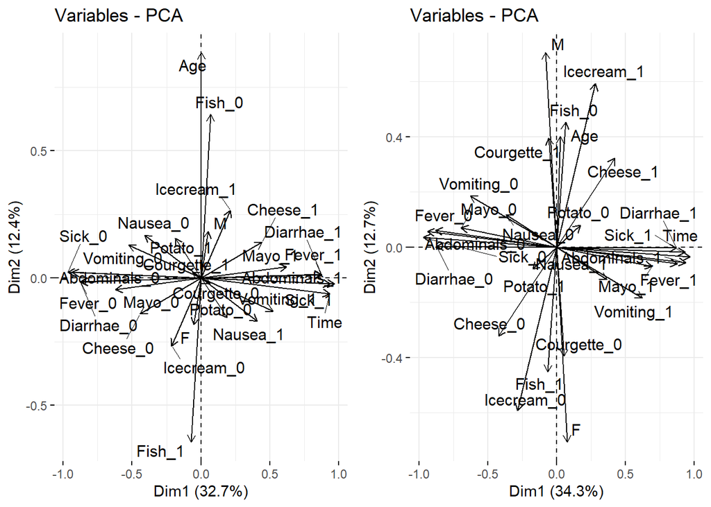

Comparación de la distribución de los variables en el espacio de las dos primeras dimensiones del MFA aplicado a la base de datos original Poison y a la amputada al 10% e imputada mediante MIRIMFA.

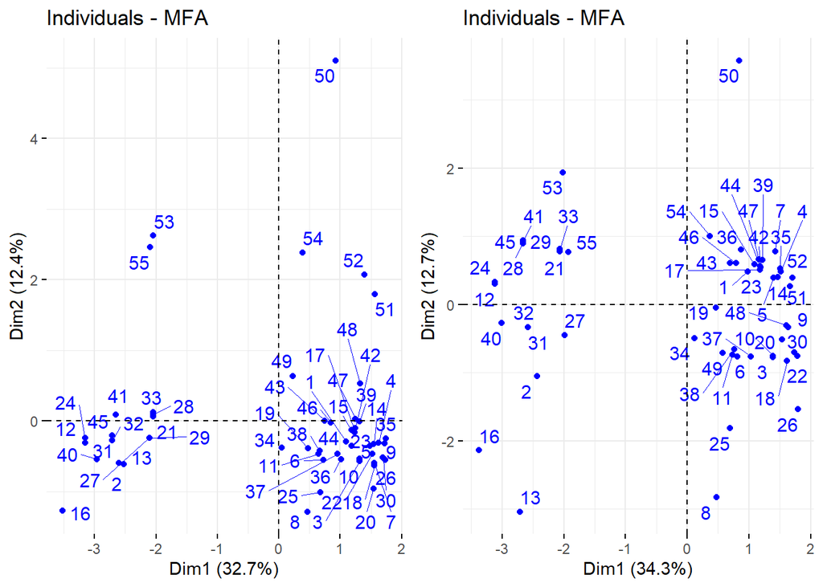

Comparación de la distribución de los individuos en el espacio de las dos primeras dimensiones del MFA aplicado a la base de datos original Poison y a la amputada al 10% e imputada mediante MIRIMFA.

Finalmente, MIRIMFA permite observar la incertidumbre. Podemos comparar las proyecciones de las imputaciones sobre el espacio compromiso.

En la figura siguiente, vemos los dos primero ejes principales de cada una de las imputaciones, donde el eje vertical y horizontal son los primeros ejes principales del espacio compromiso. Como vemos, están alineados de forma casi perfecta, aunque el segundo eje aparece rotado para algunas de las imputaciones. Esto es natural y esperable y una de las razones por la que usamos el procedimiento ACT-STATIS: porque es robusto a las rotaciones. Los resultados de esta gráfica nos dicen que la dispersión es poca y la imputación es buena.

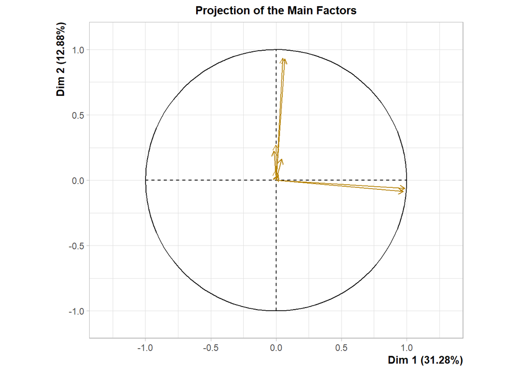

Proyección de los factores del MFA aplicado a las imputaciones sobre los dos primeros ejes del espacio compromiso de la base de datos Poison al 10% de amputación

Por otra parte, en la gráfica siguiente vemos las variables proyectadas sobre las primeras dimensiones del espacio compromiso. Con una cruz vemos todas las imputaciones individuales y con un círculo vemos marcada la variable del espacio compromiso. Si todas coinciden, el mapeo es perfecto. Mientras más dispersas estén las variables individuales con respecto al compromiso, más se tiene que desconfiar de la imputación múltiple.

Como se puede ver, la mayoría de las variables individuales coinciden con el compromiso, aunque algunas se desvían, pero en general coinciden tan bien que se enciman pareciendo una sola cruz rodeada por el círculo.

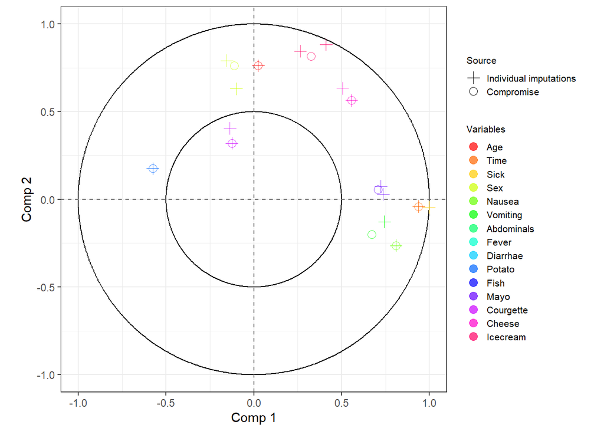

Proyección de las variables de los MFAs aplicados tanto a las imputaciones como a su compromiso sobre los dos primeros ejes del espacio compromiso de la base de datos Poison al 10% de amputación

Con estos resultados, concluimos la ejemplificación de MIRIMFA en un caso con 10% de datos faltantes. En la siguiente sección, exploraremos su desempeño con mayores porcentajes de datos perdidos.